# Data Overview

The data is a tweet archive of **@dogs_rates**, a twitter account, and file contains predictions for dog stage based on dogs' images with three different prediction methods

**Sharings of each Dog Stage**

It Looks like "Pupper" has alot of fans!

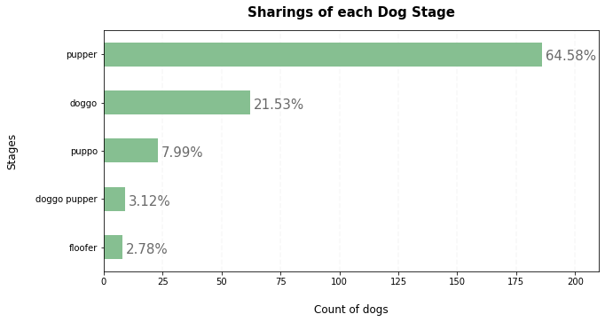

```python
#Stages to be visualized

stage_df = wrangled_data_df[wrangled_data_df['stage'] != 'None' ]

#drawing horizontal bar chart for the dog's stages
ax = stage_df['stage'].value_counts().plot(kind = 'barh', figsize = (10,5), color = '#86bf91', zorder = 2, width = 0.5);
# Draw vertical axis lines
vals = ax.get_xticks()

for tick in vals:
        ax.axvline(x = tick, linestyle = 'dashed', alpha = 0.4, color = '#eeeeee', zorder = 1)

# Set x-axis label
ax.set_xlabel("Count of dogs", labelpad = 20, size = 12)

# Set y-axis label
ax.set_ylabel("Stages", labelpad = 20, size=12);

# create a list to collect the plt.patches data
totals = []

# find the values and append to list
for i in ax.patches:
    totals.append(i.get_width())

# set individual bar lables using above list
total = sum(totals)

# set individual bar lables using above list
for i in ax.patches:
    # get_width pulls left or right; get_y pushes up or down
    ax.text(i.get_width()+1.5, i.get_y()+.38, \
            str(round((i.get_width()/total)*100, 2))+'%', fontsize=15,color='dimgrey')

# invert for largest on top
ax.invert_yaxis()

ax.set_title('Sharings of each Dog Stage', fontdict = {'fontsize' : 15, 'fontweight' : 'bold'}, pad = 15);
```

So, "Pupper" must have the highest average rating!

What! It doesn't!

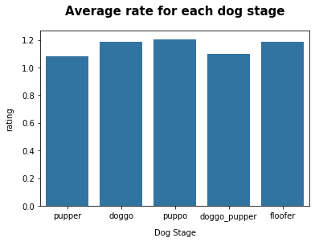

```python
wdpupperrate = wrangled_data_df.query('stage == "pupper"')['rate']
wdpupperrate_mean = wdpupperrate.mean()
wddoggorate = wrangled_data_df.query('stage == "doggo"')['rate']
wddoggorate_mean = wddoggorate.mean()
wdpupporate = wrangled_data_df.query('stage == "puppo"')['rate']
wdpupporate_mean = wdpupporate.mean()
wddoggo_pupperrate = wrangled_data_df.query('stage == "doggo pupper"')['rate']
wddoggo_pupperrate_mean = wddoggo_pupperrate.mean()
wdflooferrate = wrangled_data_df.query('stage == "floofer"')['rate']
wdflooferrate_mean = wdflooferrate.mean()

y1 = [wdpupperrate_mean, wddoggorate_mean, wdpupporate_mean, wddoggo_pupperrate_mean, wdflooferrate_mean]
x1 = ['pupper', 'doggo', 'puppo', 'doggo_pupper', 'floofer']

sns.barplot(x = x1, y = y1, color = sns.color_palette()[0]).set_title('Average rate for each dog stage', pad = 20, fontsize = 15, fontdict = {'fontweight': 'bold'});

plt.xlabel('Dog Stage', labelpad = 10);
plt.ylabel('rating', labelpad = 10);
```

**let's see rating distribution for each of dog stages**

Althoug it is not so far from the lead, it doesn't make sense!, let's see another fator

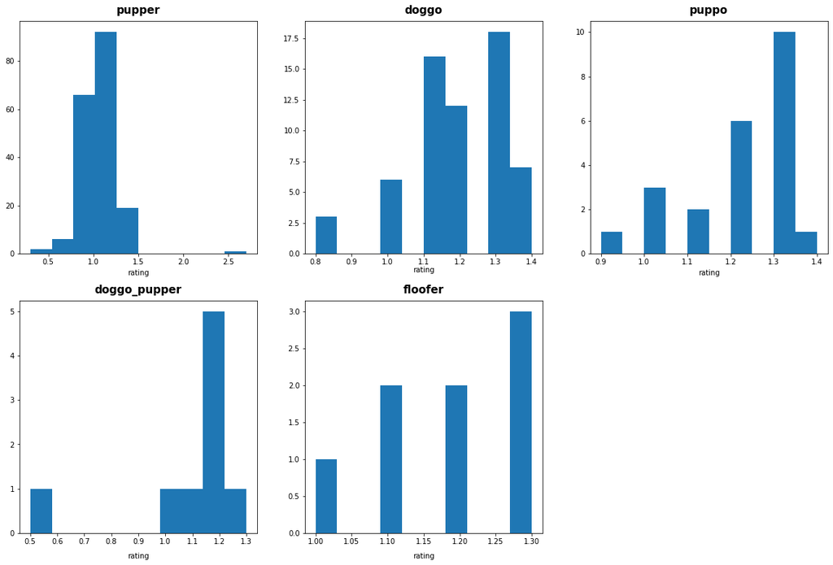

```python
plt.figure(figsize = [20,13]);

plt.subplot(2,3,1);

plt.hist(wdpupperrate);
plt.title ('pupper', pad = 10, fontsize = 15, fontdict = {'fontweight': 'bold'});
plt.xlabel('rating', labelpad = 5);

plt.subplot(2,3,2);

plt.hist(wddoggorate);
plt.title ('doggo', pad = 10, fontsize = 15, fontdict = {'fontweight': 'bold'});
plt.xlabel('rating', labelpad = 1);

plt.subplot(2,3,3);

plt.hist(wdpupporate);
plt.title ('puppo', pad = 10, fontsize = 15, fontdict = {'fontweight': 'bold'});
plt.xlabel('rating', labelpad = 5);

plt.subplot(2,3,4);

plt.hist(wddoggo_pupperrate);
plt.title ('doggo_pupper', pad = 10, fontsize = 15, fontdict = {'fontweight': 'bold'});
plt.xlabel('rating', labelpad = 10);

plt.subplot(2,3,5);

plt.hist(wdflooferrate);
plt.title ('floofer', pad = 10, fontsize = 15, fontdict = {'fontweight': 'bold'});
plt.xlabel('rating', labelpad = 10);
```

**Distribution of favorite and retweet counts**

Most of the images got retweets and fav.s between 0 and 10k

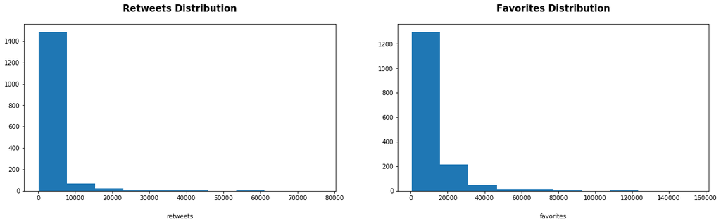

```python
plt.figure(figsize = [20,5]);

plt.subplot(1,2,1);

plt.hist(wrangled_data_df['retweet_count']);
plt.title('Retweets Distribution', pad = 20, fontsize = 15, fontdict = {'fontweight' : 'bold'});
plt.xlabel('retweets', labelpad = 20);

plt.subplot(1,2,2);

plt.hist(wrangled_data_df['favorite_count']);

plt.title('Favorites Distribution', pad = 20, fontsize = 15, fontdict = {'fontweight' : 'bold'});
plt.xlabel('favorites', labelpad = 20);
```

**What is the relationtship between number of retweets and favorites?**

The direct increase between retweets and favorites illustrates a positive relationship between the two variables

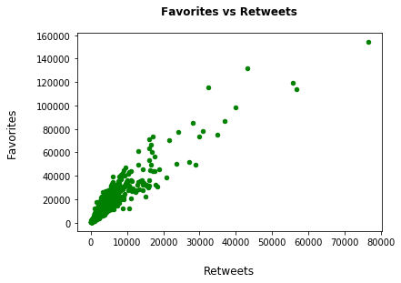

```python
retweets_count  = wrangled_data_df['retweet_count']
favorites_count = wrangled_data_df['favorite_count']



tweet_impressions = pd.concat([retweets_count,favorites_count], axis = 1)

ax = tweet_impressions.plot.scatter(x = 'retweet_count', y = 'favorite_count', color = 'green')

#Set x-axis label
ax.set_xlabel("Retweets", labelpad=20, size=12)

# Set y-axis label
ax.set_ylabel("Favorites", labelpad=20, size=12);

#set title

ax.set_title('Favorites vs Retweets', fontdict = {'fontsize' : 12, 'fontweight' : 'bold'}, pad = 20);
```

**So, does the stage affects that relationship?**

All visualizations show a direct relationship betweent number of retweet count and favotie count, yet there is a slight differnce in the relationship as number of retweets increase, like the case of "doggo", as the retweet count get above 20k the favorite count increases slower. On the other hand, in case of "floofer" just as retweet count reaches between 2k and 4k favorite count increase sharply,that is obvious due to the lack of data points.

Although pupper has high favorite and retweet counts, it is still doesn't leads the counts compared to other stages, and may be it large fan base comes from factors other than thoses available in the data, (favorites counts, retweets counts or ratings)

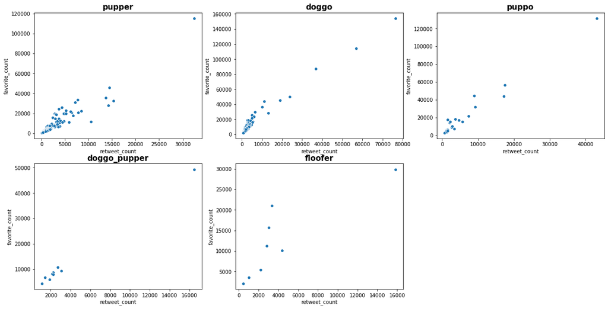

```python
wdpupper = wrangled_data_df[wrangled_data_df['stage'] == "pupper"]

wddoggo = wrangled_data_df[wrangled_data_df['stage'] == "doggo"]

wdpuppo = wrangled_data_df[wrangled_data_df['stage'] == "puppo"]

wddoggo_pupper = wrangled_data_df[wrangled_data_df['stage'] == "doggo pupper"]

wdfloofer = wrangled_data_df[wrangled_data_df['stage'] == "floofer"]

color = sns.color_palette()[0]

plt.figure(figsize = [20,10]);

#pupper plot

plt.subplot(2,3,1);

sns.scatterplot(data = wdpupper, x = 'retweet_count', y = 'favorite_count', color = color).set_title('pupper',  fontdict = {'fontsize' : 15, 'fontweight' : 'bold'});

#doggo plot

plt.subplot(2,3,2);

sns.scatterplot(data = wddoggo, x = 'retweet_count', y = 'favorite_count', color = color).set_title('doggo',  fontdict = {'fontsize' : 15, 'fontweight' : 'bold'});

#puppo plot

plt.subplot(2,3,3);

sns.scatterplot(data = wdpuppo, x = 'retweet_count', y = 'favorite_count', color = color).set_title('puppo',  fontdict = {'fontsize' : 15, 'fontweight' : 'bold'});


#doggo pupper plot

plt.subplot(2,3,4);

sns.scatterplot(data = wddoggo_pupper, x = 'retweet_count', y = 'favorite_count', color = color).set_title('doggo_pupper',  fontdict = {'fontsize' : 15, 'fontweight' : 'bold'});

#floofer plot

plt.subplot(2,3,5);

sns.scatterplot(data = wdfloofer, x = 'retweet_count', y = 'favorite_count', color = color).set_title('floofer',  fontdict = {'fontsize' : 15, 'fontweight' : 'bold'});
```

**Frequency of success for each prediction method (General Look)**

Second method leads with a little margin.

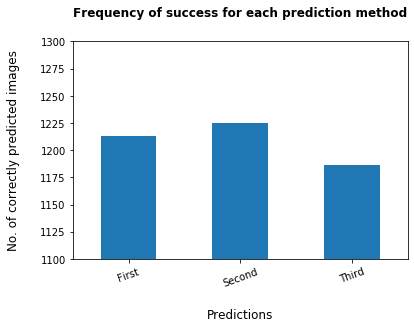

```python
p1_percent = wrangled_data_df['p1_dog'].value_counts()[True]
p2_percent = wrangled_data_df['p2_dog'].value_counts()[True]
p3_percent = wrangled_data_df['p3_dog'].value_counts()[True]

correct_pred = [p1_percent, p2_percent, p3_percent]

index = ['First', 'Second', 'Third']

pred_plot = pd.DataFrame({'Correct': correct_pred}, index=index)

ax = pred_plot.plot.bar(legend=None)

plt.xticks(rotation = 20)

#Set x-axis label
ax.set_xlabel("Predictions", labelpad=20, size=12)

# Set y-axis label
ax.set_ylabel("No. of correctly predicted images", labelpad=20, size=12);

ax.axis(ymin = 1100, ymax = 1300);

ax.set_title('Frequency of success for each prediction method', fontdict = {'fontsize' : 12, 'fontweight' : 'bold'}, pad = 25);
```

**But how reliable each of three methods?**

Distribution of confirmation percentage for each of the three methods can help, as well as number of False vs Correct Predictions.

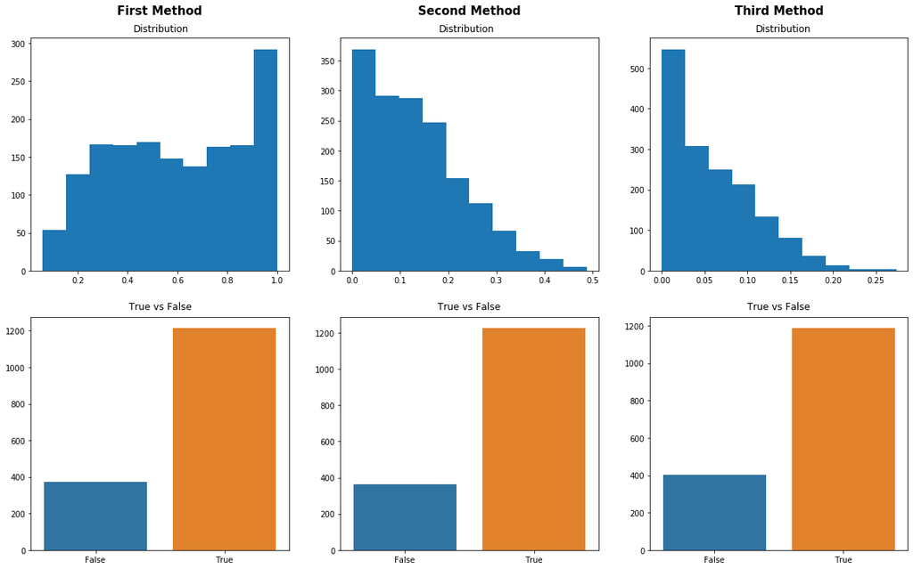

```python
plt.figure(figsize = [20,12])

#First Method distribution

plt.subplot(2,3,1);
plt.hist(wrangled_data_df['p1_conf']);
plt.title('First Method', pad = 30, fontsize = 15,fontdict = {'fontweight':'bold'});
plt.axes([.1,.1,.8,.7])
plt.figtext(.51,.89,'Distribution',fontsize = 12,ha = 'center')
plt.xlabel('conf');

#Second Method distribution

plt.subplot(2,3,2);

plt.hist(wrangled_data_df['p2_conf']);
plt.title('Second Method', pad = 30, fontsize = 15,fontdict = {'fontweight':'bold'});
plt.axes([.1,.1,.8,.7])
plt.figtext(.24,.89,'Distribution',fontsize = 12,ha = 'center')
plt.xlabel('conf');

#Third Method distribution

plt.subplot(2,3,3);

plt.hist(wrangled_data_df['p3_conf']);
plt.title('Third Method', pad = 30, fontsize = 15,fontdict = {'fontweight':'bold'});
plt.axes([.1,.1,.8,.7])
plt.figtext(.79,.89,'Distribution',fontsize = 12,ha = 'center')
plt.xlabel('conf');

# First Method True vs False

ax1 = plt.subplot(2,3,4);

x1 = wrangled_data_df['p1_dog'].value_counts().index.tolist()
y1 = wrangled_data_df['p1_dog'].value_counts().tolist()

sns.barplot(x1,y1);
plt.title('True vs False', pad = 10, fontsize = 12);

# Second Method True Vs False

ax2 = plt.subplot(2,3,5);

x2 = wrangled_data_df['p2_dog'].value_counts().index.tolist()
y2 = wrangled_data_df['p2_dog'].value_counts().tolist()

sns.barplot(x2,y2);
plt.title('True vs False', pad = 10, fontsize = 12);

#Third Method True vs False

ax3 = plt.subplot(2,3,6);

x3 = wrangled_data_df['p3_dog'].value_counts().index.tolist()
y3 = wrangled_data_df['p3_dog'].value_counts().tolist()

sns.barplot(x3,y3);
plt.title('True vs False', pad = 10, fontsize = 12);
```

**Let's have a deeper look on the effect of each stage on that method success race**

It looks so, for "pupper" and "doggo" stages second method has higher success predictions, and equal success predictions of the firts and second methods for "floofer" stage. First method has a little higher successes when the stage is "doggo puppo", and third method has the highest successes when the dog stage is "puppo".

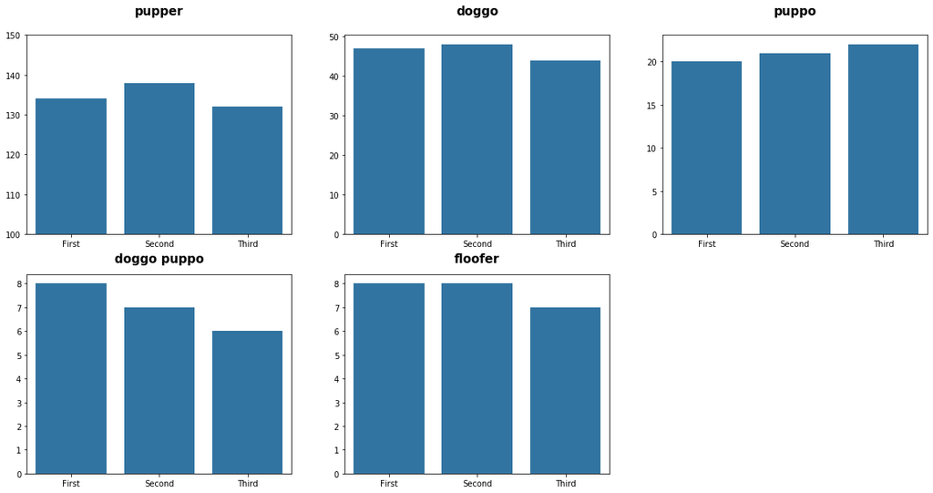

```python
color = sns.color_palette()[0]

plt.figure(figsize = [20,10]);

#pupper plot

plt.subplot(2,3,1);

p1_pupper = wdpupper['p1_dog'].value_counts()[True]
p2_pupper = wdpupper['p2_dog'].value_counts()[True]
p3_pupper = wdpupper['p3_dog'].value_counts()[True]

pupper_correct_pred = [p1_pupper, p2_pupper, p3_pupper]
ax.axis(ymin = 1100, ymax = 1300);
plt.ylim(100, 150)
sns.barplot(x = index, y = pupper_correct_pred, color = color, dodge = False).set_title('pupper', fontdict = {'fontsize' : 15, 'fontweight' : 'bold'}, pad = 25);

#doggo plot

plt.subplot(2,3,2);

p1_doggo = wddoggo['p1_dog'].value_counts()[True]
p2_doggo = wddoggo['p2_dog'].value_counts()[True]
p3_doggo = wddoggo['p3_dog'].value_counts()[True]

doggo_correct_pred = [p1_doggo, p2_doggo, p3_doggo]
sns.barplot(x = index, y = doggo_correct_pred, color = color, dodge = False).set_title('doggo', fontdict = {'fontsize' : 15, 'fontweight' : 'bold'}, pad = 25);

#puppo plot

plt.subplot(2,3,3);

p1_puppo = wdpuppo['p1_dog'].value_counts()[True]
p2_puppo = wdpuppo['p2_dog'].value_counts()[True]
p3_puppo = wdpuppo['p3_dog'].value_counts()[True]

puppo_correct_pred = [p1_puppo, p2_puppo, p3_puppo]
sns.barplot(x = index, y = puppo_correct_pred, color = color, dodge = False).set_title('puppo', fontdict = {'fontsize' : 15, 'fontweight' : 'bold'}, pad = 25);

#doggo pupper plot

plt.subplot(2,3,4);

p1_doggo_pupper = wddoggo_pupper['p1_dog'].value_counts()[True]
p2_doggo_pupper = wddoggo_pupper['p2_dog'].value_counts()[True]
p3_doggo_pupper = wddoggo_pupper['p3_dog'].value_counts()[True]

doggo_pupper_correct_pred = [p1_doggo_pupper, p2_doggo_pupper, p3_doggo_pupper]
sns.barplot(x = index, y = doggo_pupper_correct_pred, color = color, dodge = False).set_title('doggo puppo', fontdict = {'fontsize' : 15, 'fontweight' : 'bold'}, pad = 15);

#floofer plot

plt.subplot(2,3,5);

p1_floofer = wdfloofer['p1_dog'].value_counts()[True]
p2_floofer = wdfloofer['p2_dog'].value_counts()[True]
p3_floofer = wdfloofer['p3_dog'].value_counts()[True]

floofer_correct_pred = [p1_floofer, p2_floofer, p3_floofer]
sns.barplot(x = index, y = floofer_correct_pred, color = color, dodge = False).set_title('floofer', fontdict = {'fontsize' : 15, 'fontweight' : 'bold'}, pad = 15 );
```

**What about the effect of retweets vs favorites count along side stages on the each prediction method conf!**

Effect on first method confirmation percentage

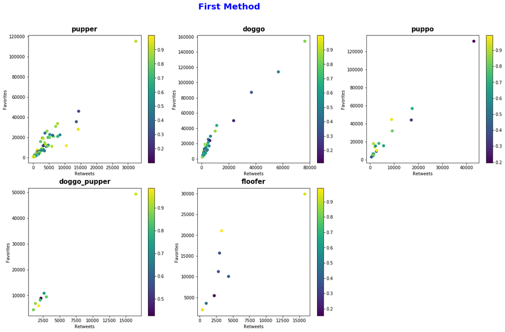

```python
wrangled_data_df_first = wrangled_data_df.query('p1_dog == True')

color = sns.color_palette()[0]

plt.figure(figsize = [20,12]);

plt.axes([.1,.1,.8,.7]);
plt.figtext(.45,.95,'First Method',fontsize = 20,ha = 'center', fontdict = {'fontweight' : 'bold' , 'color' : 'blue'});

#pupper plot

plt.subplot(2,3,1);

wdpupper_first = wrangled_data_df_first.query('stage == "pupper"')

plt.scatter(data = wdpupper_first, x = 'retweet_count' , y = 'favorite_count', c = 'p1_conf');
plt.colorbar();
plt.title('pupper', fontdict = {'fontsize' : 15, 'fontweight' : 'bold'}, pad = 10);
plt.xlabel("Retweets")
plt.ylabel("Favorites");

#doggo plot

plt.subplot(2,3,2);

wddoggo_first = wrangled_data_df_first.query('stage == "doggo"')

plt.scatter(data = wddoggo_first, x = 'retweet_count', y = 'favorite_count', c = 'p1_conf');
plt.colorbar();
plt.title('doggo', fontdict = {'fontsize' : 15, 'fontweight' : 'bold'}, pad = 10);
plt.xlabel("Retweets")
plt.ylabel("Favorites");

#puppo plot

plt.subplot(2,3,3);

wdpuppo_first = wrangled_data_df_first.query('stage == "puppo"')

plt.scatter(data = wdpuppo_first,x = 'retweet_count', y = 'favorite_count', c = 'p1_conf');
plt.colorbar();
plt.title('puppo', fontdict = {'fontsize' : 15, 'fontweight' : 'bold'}, pad = 10);
plt.xlabel("Retweets")
plt.ylabel("Favorites");

#doggo pupper plot

plt.subplot(2,3,4);

wddoggo_pupper_first = wrangled_data_df_first.query('stage == "doggo pupper"')

plt.scatter(data = wddoggo_pupper_first,x = 'retweet_count', y = 'favorite_count', c = 'p1_conf');
plt.colorbar();
plt.title('doggo_pupper', fontdict = {'fontsize' : 15, 'fontweight' : 'bold'}, pad = 10);
plt.xlabel("Retweets")
plt.ylabel("Favorites");

#floofer plot

plt.subplot(2,3,5);

wdfloofer_first = wrangled_data_df_first.query('stage == "floofer"')

plt.scatter(data = wdfloofer_first,x = 'retweet_count', y = 'favorite_count', c = 'p1_conf');
plt.colorbar();
plt.title('floofer', fontdict = {'fontsize' : 15, 'fontweight' : 'bold'}, pad = 10);
plt.xlabel("Retweets")
plt.ylabel("Favorites");
```

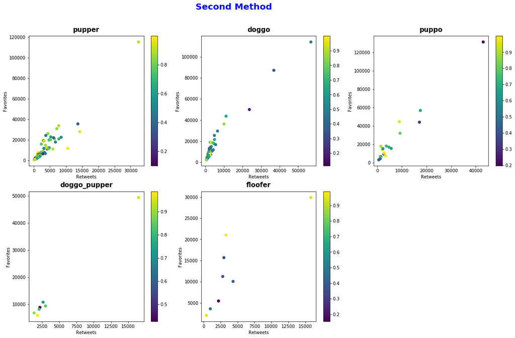

```python
wrangled_data_df_second = wrangled_data_df.query('p2_dog == True')

color = sns.color_palette()[0]

plt.figure(figsize = [20,12]);

plt.axes([.1,.1,.8,.7]);
plt.figtext(.45,.95,'Second Method',fontsize = 20,ha = 'center', fontdict = {'fontweight' : 'bold' , 'color' : 'blue'});

#pupper plot

plt.subplot(2,3,1);

wdpupper_second = wrangled_data_df_second.query('stage == "pupper"')

plt.scatter(data = wdpupper_second, x = 'retweet_count' , y = 'favorite_count', c = 'p1_conf');
plt.colorbar();
plt.title('pupper', fontdict = {'fontsize' : 15, 'fontweight' : 'bold'}, pad = 10);
plt.xlabel("Retweets")
plt.ylabel("Favorites");

#doggo plot

plt.subplot(2,3,2);

wddoggo_second = wrangled_data_df_second.query('stage == "doggo"')

plt.scatter(data = wddoggo_second, x = 'retweet_count', y = 'favorite_count', c = 'p1_conf');
plt.colorbar();
plt.title('doggo', fontdict = {'fontsize' : 15, 'fontweight' : 'bold'}, pad = 10);
plt.xlabel("Retweets")
plt.ylabel("Favorites");

#puppo plot

plt.subplot(2,3,3);

wdpuppo_second = wrangled_data_df_second.query('stage == "puppo"')

plt.scatter(data = wdpuppo_second,x = 'retweet_count', y = 'favorite_count', c = 'p1_conf');
plt.colorbar();
plt.title('puppo', fontdict = {'fontsize' : 15, 'fontweight' : 'bold'}, pad = 10);
plt.xlabel("Retweets")
plt.ylabel("Favorites");

#doggo pupper plot

plt.subplot(2,3,4);

wddoggo_pupper_second = wrangled_data_df_second.query('stage == "doggo pupper"')

plt.scatter(data = wddoggo_pupper_second,x = 'retweet_count', y = 'favorite_count', c = 'p1_conf');
plt.colorbar();
plt.title('doggo_pupper', fontdict = {'fontsize' : 15, 'fontweight' : 'bold'}, pad = 10);
plt.xlabel("Retweets")
plt.ylabel("Favorites");

#floofer plot

plt.subplot(2,3,5);

wdfloofer_second = wrangled_data_df_second.query('stage == "floofer"')

plt.scatter(data = wdfloofer_second,x = 'retweet_count', y = 'favorite_count', c = 'p1_conf');
plt.colorbar();
plt.title('floofer', fontdict = {'fontsize' : 15, 'fontweight' : 'bold'}, pad = 10);
plt.xlabel("Retweets")
plt.ylabel("Favorites");
```

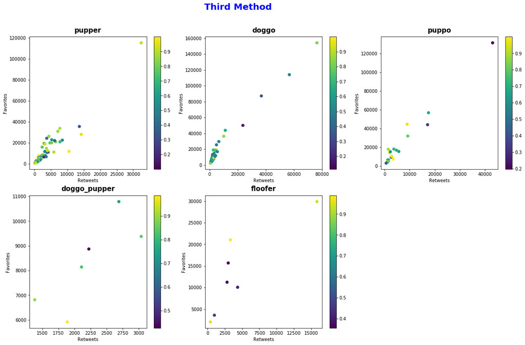

```python
wrangled_data_df_third = wrangled_data_df.query('p3_dog == True')

color = sns.color_palette()[0]

plt.figure(figsize = [20,12]);

plt.axes([.1,.1,.8,.7]);
plt.figtext(.45,.95,'Third Method',fontsize = 20,ha = 'center', fontdict = {'fontweight' : 'bold' , 'color' : 'blue'});

#pupper plot

plt.subplot(2,3,1);

wdpupper_third = wrangled_data_df_third.query('stage == "pupper"')

plt.scatter(data = wdpupper_third, x = 'retweet_count' , y = 'favorite_count', c = 'p1_conf');
plt.colorbar();
plt.title('pupper', fontdict = {'fontsize' : 15, 'fontweight' : 'bold'}, pad = 10);
plt.xlabel("Retweets")
plt.ylabel("Favorites");

#doggo plot

plt.subplot(2,3,2);

wddoggo_third = wrangled_data_df_third.query('stage == "doggo"')

plt.scatter(data = wddoggo_third, x = 'retweet_count', y = 'favorite_count', c = 'p1_conf');
plt.colorbar();
plt.title('doggo', fontdict = {'fontsize' : 15, 'fontweight' : 'bold'}, pad = 10);
plt.xlabel("Retweets")
plt.ylabel("Favorites");

#puppo plot

plt.subplot(2,3,3);

wdpuppo_third = wrangled_data_df_third.query('stage == "puppo"')

plt.scatter(data = wdpuppo_third,x = 'retweet_count', y = 'favorite_count', c = 'p1_conf');
plt.colorbar();
plt.title('puppo', fontdict = {'fontsize' : 15, 'fontweight' : 'bold'}, pad = 10);
plt.xlabel("Retweets")
plt.ylabel("Favorites");

#doggo pupper plot

plt.subplot(2,3,4);

wddoggo_pupper_third = wrangled_data_df_third.query('stage == "doggo pupper"')

plt.scatter(data = wddoggo_pupper_third,x = 'retweet_count', y = 'favorite_count', c = 'p1_conf');
plt.colorbar();
plt.title('doggo_pupper', fontdict = {'fontsize' : 15, 'fontweight' : 'bold'}, pad = 10);
plt.xlabel("Retweets")
plt.ylabel("Favorites");

#floofer plot

plt.subplot(2,3,5);

wdfloofer_third = wrangled_data_df_third.query('stage == "floofer"')

plt.scatter(data = wdfloofer_third,x = 'retweet_count', y = 'favorite_count', c = 'p1_conf');
plt.colorbar();
plt.title('floofer', fontdict = {'fontsize' : 15, 'fontweight' : 'bold'}, pad = 10);
plt.xlabel("Retweets")
plt.ylabel("Favorites");
```

# To summer up

**As for dog's stages**,

Dogs of " Pupper " stage has large fans base, but it still doesn't lead the counts compared to other stages, and may be its large fan base comes from factors other than thoses available in the data, (favorites counts, retweets counts or ratings). Eventhough "Rating" has no availabe enough data to define the word.

**As for prediction methods**,

Although second prediction method has higher correct predictions, but first prediction method yet stands as the most reliable one depending on its confirmation percentage to number of correctly predicted images. Favorites and retweets counts and dogs' stages doesn't show considerable effect on prediction accuracy